# EAS 648 Lab 4

Kunxi Li

2023-11-17

## Assignment

### Questions

1. Utilize sentiment analysis to study a textual document in a manner you find suitable. Select a lexicon library for assessing the sentiment of the dataset, such as determining whether it is positive, negative, or joyous. Present your findings using appropriate charts and provide an explanation of the results in 1-2 paragraphs.

I choose Jorge Luis Borges’s novel, *A Universal History of Infamy*, as the textual data source. Unlike the positive characters found in traditional novels, *A Universal History of Infamy* portrays a series of anti-heroes. However, Borges does not always depict these characters in negative tones. Instead, he frequently uses humor, irony, and sarcasm to highlight their traits. I believe conducting a sentiment analysis on this novel would be very interesting.

1. Data Tidy Use `readLines` function to load the text data and convert it to dataframe, then according to the ‘Chapter’ showed up in the text, detect the lines and add the variables that indicate the chapter to which the sentence belongs. Finally Create another new variable that indicates the index number of the chapter of the sentence.

```r
library(dplyr)
library(tidytext)
library(textdata)
library(tidyverse)
```

```r
data <- readLines('infamy.txt')

# Initialize empty data frame
infamy_df <- data.frame(chapter = character(), text = character(), stringsAsFactors = FALSE)

current_chapter <- NA
for (line in data) {
  if (startsWith(line, "Chapter ")) {
    # If line starts with "Chapter", update current_chapter
    current_chapter <- sub("Chapter ", "", line)
  } else if (nchar(line) > 0){
    # Otherwise, it's a line of text in the current chapter, add to your data frame
    infamy_df <- rbind(infamy_df, data.frame(chapter = current_chapter, text = line, stringsAsFactors = FALSE))
  }
}
infamy_df <- infamy_df[4:333,]
infamy_df$chapter_n <- as.numeric(str_extract(infamy_df$chapter, "\\d+"))
infamy_df$chapter <- sub("^\\d+\\s*", "", infamy_df$chapter)
```

2. Dara Segmentation Add a variable ‘sentence_id’ that indicates the row number within each chapter and then use `unnest_tokens` function to segment to sentences into single words.

```r
tidy_infamy <- infamy_df %>%
  group_by(chapter) %>%
  mutate(sentence_id = row_number()) %>% # add sentence index within each chapter
  ungroup() %>%
  unnest_tokens(word, text)
```

3. Sentimental Analysis Use “bing” as the sentiment lexicon to conduct the sentimental analysis based on single words using `inner_join` function to compare the lexicon with the words.

```r
infamy_sentiment <- tidy_infamy %>%
  inner_join(get_sentiments("bing")) %>%
  count(chapter, index = sentence_id, sentiment) %>%
  spread(sentiment, n, fill = 0) %>%
  mutate(sentiment = positive - negative)
```

Plot the results to visualize the sentiment of the chapters for the novel.

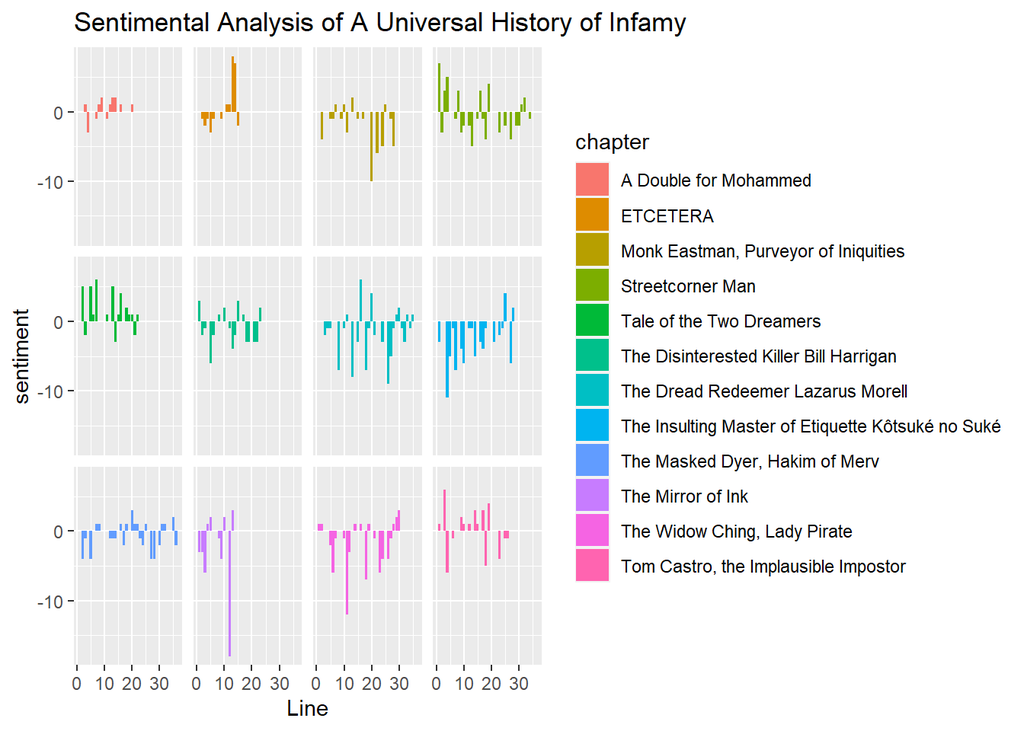

```r
ggplot(infamy_sentiment, aes(index, sentiment, fill = chapter)) +
  geom_col(show.legend = TRUE) +
  facet_wrap(~chapter)+
  theme(strip.text = element_blank())+
  xlab('Line')+
  ggtitle("Sentimental Analysis of A Universal History of Infamy")
```

3. positive and negative words Evaluation Inner join the lexicon and data and then count the number of words based on positive and negative sentiment.

```r
infamy_bing_word_counts <- tidy_infamy %>%
  inner_join(get_sentiments("bing")) %>%
  count(word, sentiment, sort = TRUE) %>%
  ungroup()
infamy_bing_word_counts
```

```
## # A tibble: 776 × 3
##    word   sentiment     n
##    <chr>  <chr>     <int>
##  1 like   positive     41
##  2 dead   negative     26
##  3 good   positive     25
##  4 death  negative     24
##  5 great  positive     24
##  6 well   positive     19
##  7 died   negative     14
##  8 knife  negative     14
##  9 heaven positive     12
## 10 desert negative     11
## # ℹ 766 more rows
```

Plot the sorted results.

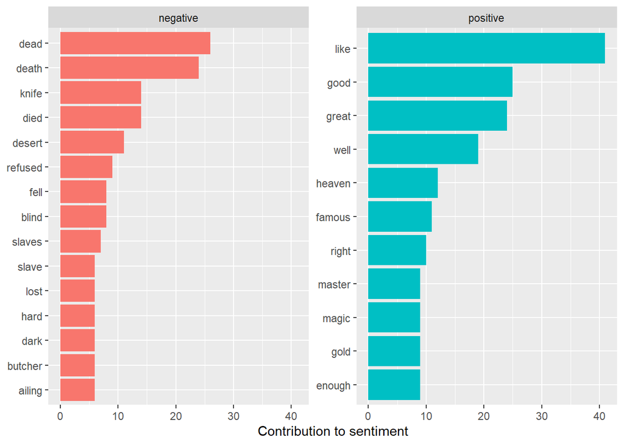

```r
infamy_bing_word_counts %>%
  group_by(sentiment) %>%
  top_n(10) %>%
  ungroup() %>%
  mutate(word = reorder(word, n)) %>%
  ggplot(aes(word, n, fill = sentiment)) +
  geom_col(show.legend = FALSE) +
  facet_wrap(~sentiment, scales = "free_y") +
  labs(y = "Contribution to sentiment",
       x = NULL) +
  coord_flip()
```

Looking at the results, we can see that even though all the chapters tell stories about villains, the author uses different ways to tell each story. This is shown by the different trends of negative and positive words in the graph. For example, ‘ETCETERA’ mostly uses negative words, but many positive words are used near the end. Also, ‘Street Corner Man’ starts with a lot of positive words, then shifts to a negative tone. When we check the most commonly used positive and negative words, we see that ‘dead’, ‘death’, ‘knife’, and ‘die’ are used quite often, which makes sense for a novel about villains. However, there are also a lot of ‘good’ and ‘great’ used, which means there could be a lot of irony or sarcasm in the novel.

2. Conduct an analysis of ambiguous text within the dataset. Reflect on and provide examples of issues related to subjectivity, tone, context, polarity, irony, sarcasm, comparisons, and the use of neutral language in 2-3 paragraphs.

1.Sentence based segmentation & Inner Join Based on the dataframe of original text of *A Universal History of Infamy*, use get_sentence to segment the data by sentence and inner join them with lexicons.

```r
library(sentimentr)
infamy_sentiment_sent <- infamy_df %>%
    get_sentences() %>%
    sentiment_by(by = c('chapter', 'sentence_id'))%>%
  as.data.frame()
```

2.Result Visualization

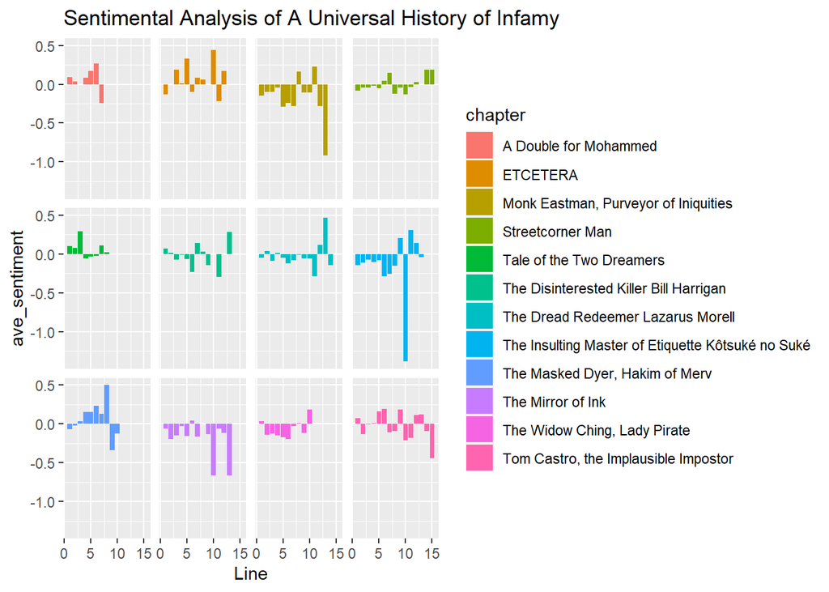

```r
ggplot(infamy_sentiment_sent, aes(sentence_id, ave_sentiment, fill = chapter)) +
  geom_col(show.legend = TRUE) +
  facet_wrap(~chapter)+
  theme(strip.text = element_blank())+
  xlab('Line')+
  ggtitle("Sentimental Analysis of A Universal History of Infamy")
```

From the results of a sentence-based sentiment analysis, it becomes evident that the emotional tone in the chapters is largely neutral, though slightly leaning towards the negative and critical. The central portions of most chapters have low absolute sentiment scores, with several sentences reporting extremely negative scores, while only a handful reflect high positive scores. Interestingly, in many chapters of the novel, Borges often writes ‘positive’ sentences near the chapter’s end, followed by negative ones. This tone is apparent in chapters such as ‘The Dread Redeemer Lazarus Morell’ and ‘Tom Castro, the Implausible Impostor’.

To illustrate this further, let’s consider a paragraph from the ‘ETCETERA’ chapter, which tells the story of a disingenuous and pompous theologian amidst some magical realism elements. Written in an understated tone and brimming with sarcasm and irony, a number of sentences make it challenging to categorize them as either positive or negative from my perspective.

Some extracts from the paragraph like: The angels told me that when Melancthon died he was provided with a house deceptively like the one in which he lived in this world. (This happens to most newcomers in eternity upon their first arrival - it is why they are ignorant of their death, and think they are still in the natural world.) All the things in his room were similar to those he had had before - the table, the desk with its drawers, the shelves of books. As soon as Melancthon awoke in this new abode, he sat at his table, took up his literary work, and spent several days writing - as usual - on justification by faith alone, without so much as a single word on charity. This omission being remarked by the angels, they sent messengers to question him. ‘I have proved beyond refutation,’ Melancthon replied to them, ‘that there is nothing in charity essential to the soul, and that to gain salvation faith is enough.’ He spoke with great assurance, unsuspecting that he was dead and that his lot lay outside Heaven. When the angels heard him say these things, they departed.

Next, I will conduct two types of sentiment analysis based on sentence and word of the text to see the results it yields.

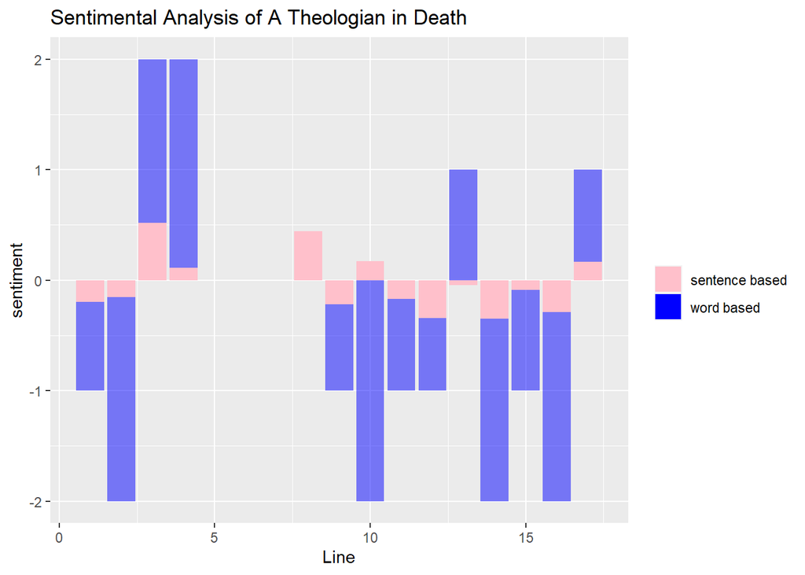

```r
theologian <- readLines('A Theologian in Death.txt')
theologian_df <- data.frame(text = character(), stringsAsFactors = FALSE)
for (line in theologian) {
    theologian_df <- rbind(theologian_df, data.frame( text = line, stringsAsFactors = FALSE))
}

tidy_theologian <- theologian_df %>%
  mutate(element_id = row_number()) %>% # add sentence index within each chapter
  ungroup() %>%
  unnest_tokens(word, text)

theologian_sentiment <- tidy_theologian %>%
  inner_join(get_sentiments("bing")) %>%
  count(element_id, sentiment) %>%
  spread(sentiment, n, fill = 0) %>%
  mutate(sentiment = positive - negative)
theologian_sentiment_sent <- theologian_df %>%
    get_sentences() %>%
    sentiment_by(by = c('element_id'))%>%
  as.data.frame()

merged_df <- merge(theologian_sentiment_sent, theologian_sentiment, by = "element_id")

ggplot(merged_df, aes(element_id)) +
  geom_col(aes(y=sentiment, fill = 'word based'), alpha = 0.5) +
  geom_col(aes(y=ave_sentiment, fill = 'sentence based'), alpha = 1.0) +
  xlab('Line') +
  ggtitle("Sentimental Analysis of A Theologian in Death") +
  scale_fill_manual(values = c('sentence based' = 'pink', 'word based' = 'blue')) +
  guides(fill=guide_legend(title=""))
```